# Writing plumbertableau Extensions in R

## Getting Started

This vignette will walk you through writing plumbertableau extensions in R. plumbertableau extensions are Plumber APIs with a few additional pieces, and this vignette assumes some familiarity with Plumber (https://www.rplumber.io/). If you’re unfamiliar with Plumber, the [Quickstart guide](https://www.rplumber.io/articles/quickstart.html) gives a good overview of that package. Throughout this guide, we’ll use the terms “web service” and “API” (application programming interface) interchangeably.

You can install the plumbertableau package from CRAN or GitHub.

```r
# from CRAN
install.packages("plumbertableau")

# from GitHub
remotes::install_github("rstudio/plumbertableau")
```

Once the package is installed, you can start a new RStudio Project with a template file from the New Project menu inside RStudio:

[figure not shown]

The package also comes with several other example extensions:

```r
plumber::available_apis(package = "plumbertableau")
```

```
#> Available Plumber APIs:
#> * plumbertableau
#>   - capitalize
#>   - loess
#>   - mounts
#>   - programmatic
#>   - stringutils
```

These examples can be run and optionally viewed using `plumber::plumb_api()`.

## What can plumbertableau Extensions Do?

plumbertableau extensions respond to requests from Tableau. In a request, Tableau will provide an [*endpoint*](https://www.rplumber.io/articles/routing-and-input.html?q=endpoint#endpoints-1) — which roughly corresponds to an R function — and will send along one or more *arguments*, which will generally consist of data from Tableau.

An extension *must* return data that’s the same number of observations as the arguments it receives. It can do things like transform text, or use a model to predict Y values from a matrix of X values. A plumbertableau extension can’t, say, receive an integer representing the number of elements to sample, and return a vector of that length.

## An Example with Loess Regression

Let’s start with some plain R code that uses the `loess()` function to fit a smooth line across some input data and plot the result.

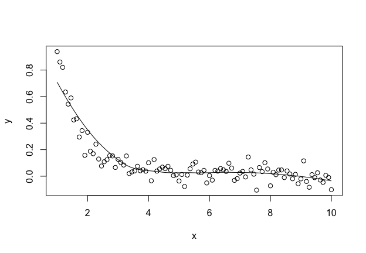

```r
x <- seq(1, 10, length.out = 100)
y <- 1/x^2 + rnorm(length(x), sd = 0.05)
fit <- loess(y ~ x, span = 0.75)
y_fit <- predict(fit, data.frame(x, y))

# Plot the data and prediction.
plot(x, y)
lines(x, y_fit)
```